# main slides

みなさん、こんにちは！

これまで毎年枚数を増やしてきたカレンダー、今年は一味違いました。

「関」「学」「自」のテーマをもとに、想像を膨らませて記事を書く。

そんな無茶振り趣向に応えていただいたみなさん、

本当にありがとうございました＆おつかれさまでした！！！

運営から感謝の気持ちをこめて、ささやかなコンテンツを用意しました。

どうぞお楽しみください！

### Looking back

# Livesense Advent Calendar 2017

### by the numbers

〜数字で振り返るリブセンスアドベントカレンダー2017〜

## 記事数・UU数

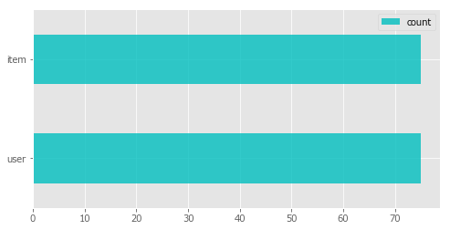

```python
df = read_sql('''
    SELECT
        COUNT(DISTINCT user_id) AS user,
        COUNT(*) AS item
    FROM
        items
''', con)
df = df.transpose()
df.columns = ['count']
df.plot.barh(color='c', alpha=0.8, figsize=(8, 4))
```

## 総いいね数

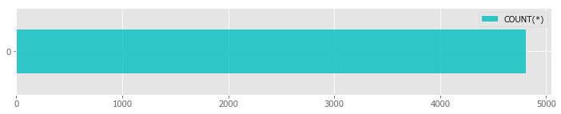

```python
df = read_sql('''
    SELECT
        COUNT(*)
    FROM
        likes
''', con)
df.plot.barh(color='c', alpha=0.8, figsize=(12, 2))
```

## いいね数 カレンダー参加者 vs それ以外

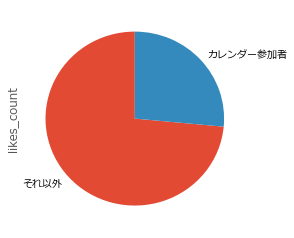

```python
df = read_sql('''
    SELECT
        calendar_participation,
        COUNT(*) AS likes_count
    FROM
        likes
        INNER JOIN users ON likes.user_id = users.id
    GROUP BY
        calendar_participation
''', con)
df['likes_count'].plot.pie(figsize=(4, 4), startangle=90, labels=['それ以外', 'カレンダー参加者'])
```

## いいね数 個人別

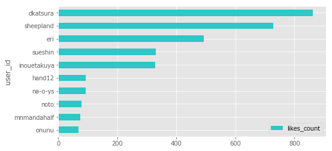

```python
df = read_sql('''
    SELECT
        user_id, likes_count
    FROM
        items
    ORDER BY
        likes_count DESC
''', con)
df[:10].iloc[::-1].plot.barh(x='user_id', y='likes_count', color='c', alpha=0.8, figsize=(8, 4))
```

## いいね数 カレンダー別

・・・の前に

合計値で競ったら、「学」圧倒的有利

- dkatsura さん
- sheepland さん

今回は合計値ではなく **中央値** で競います！

## いいね数 カレンダー別 (中央値)

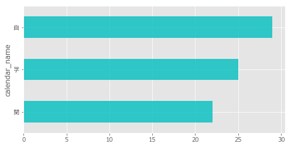

```python
df = read_sql('''
    SELECT
        calendar_name, calendar_date, likes_count
    FROM
        items
''', con)
df = df.pivot(index='calendar_date', columns='calendar_name', values='likes_count')
df.median().sort_values().plot.barh(color='c', alpha=0.8, figsize=(8, 4))
```

## カレンダーの差はどこで生まれた？

## いいね数の分布

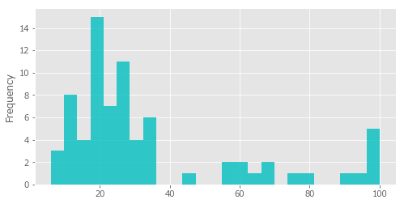

```python
df = read_sql('''
    SELECT
        user_id, likes_count
    FROM
        items
    ORDER BY
        likes_count DESC
''', con)
df['likes_count'].map(lambda x: min(x, 100)).plot.hist(bins=25, color='c', alpha=0.8, figsize=(8, 4))
```

## いいね数の分布 カレンダー別

[output not shown]

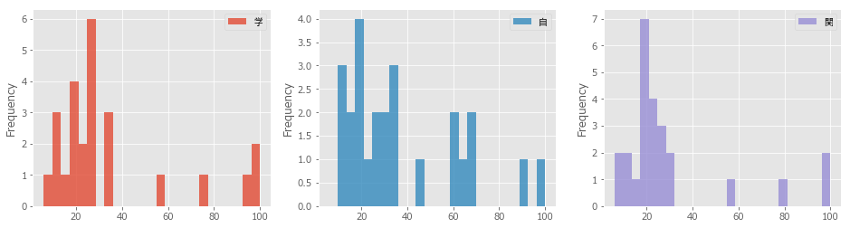

```python
df = read_sql('''
    SELECT
        calendar_name, calendar_date, likes_count
    FROM
        items
''', con)
df = df.pivot(index='calendar_date', columns='calendar_name', values='likes_count')
df = df.applymap(lambda x: min(x, 100))
df.plot.hist(bins=25, alpha=0.8, subplots=True, layout=(1, 3), figsize=(16, 4))
```

## 最も１位の日が多かったカレンダーは？

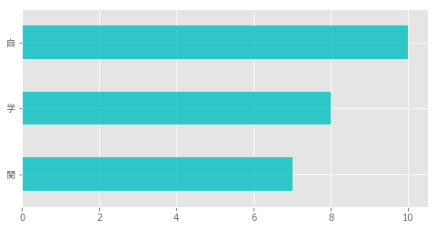

```python
df = read_sql('''
    SELECT
        calendar_name, calendar_date, likes_count
    FROM
        items
''', con)
df = df.pivot(index='calendar_date', columns='calendar_name', values='likes_count')
df.apply(lambda row: row.idxmax(), axis=1).value_counts().sort_values(ascending=True) .plot.barh(color='c', alpha=0.8, figsize=(8, 4))
```

## Qiita人気ユーザに多くいいねされた記事は？

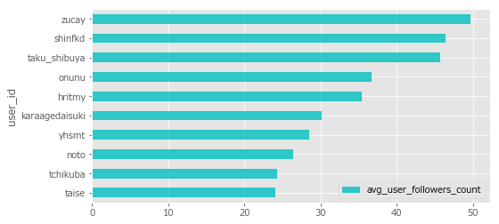

```python
df = read_sql('''
    SELECT
        items.user_id,
        -- 記事にいいねしたQiitaユーザのフォロワー数の平均値
        AVG(users.followers_count) AS avg_user_followers_count
    FROM
        likes
        INNER JOIN items ON likes.item_id = items.id
        INNER JOIN users ON likes.user_id = users.id
    GROUP BY
        items.user_id
    HAVING
        COUNT(likes.user_id) >= 20
    ORDER BY
        avg_user_followers_count DESC
''', con)
df[:10].iloc[::-1].plot.barh(x='user_id', y='avg_user_followers_count', color='c', alpha=0.8, figsize=(8, 4))
```

## 誰が誰にいいねしてる？

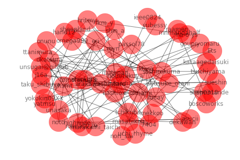

```python
from networkx import from_pandas_dataframe, spring_layout, draw
df = read_sql('''
    WITH tmp_users AS (
        SELECT
            likes.user_id
        FROM
            likes
            INNER JOIN users ON likes.user_id = users.id
        WHERE
            users.calendar_participation = 1
        GROUP BY
            likes.user_id
        HAVING
            COUNT(*) <= 10
    )
    SELECT
        likes.user_id AS from_user,
        items.user_id AS to_user
    FROM
        likes
        INNER JOIN items ON likes.item_id = items.id
    WHERE
        likes.user_id IN tmp_users
''', con)
graph = from_pandas_dataframe(df, 'from_user', 'to_user')
pos = spring_layout(graph, k=1.5)
draw(graph, pos=pos, with_labels=True, node_size=1500, alpha=0.5, arrows=True, )
```

## PageRankしてみたら？

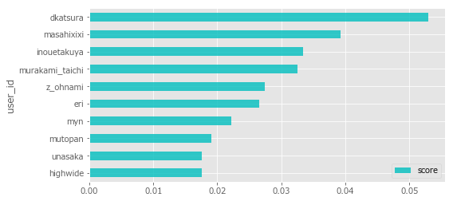

```python
from networkx import from_pandas_dataframe, DiGraph, pagerank
df = read_sql('''
    SELECT
        likes.user_id AS from_user,
        items.user_id AS to_user
    FROM
        likes
        INNER JOIN items ON likes.item_id = items.id
        INNER JOIN users ON likes.user_id = users.id
    WHERE
        users.calendar_participation = 1
''', con)
graph = from_pandas_dataframe(df, source='from_user', target='to_user', create_using=DiGraph())
ranking = pagerank(graph) # PageRank
df = DataFrame([{'user_id': k, 'score': v} for k, v in ranking.items()], columns=['user_id', 'score'])
df = df.sort_values(by='score', ascending=False)
df[:10].iloc[::-1].plot.barh(x='user_id', y='score', color='c', alpha=0.8, figsize=(8, 4))
```

なかなか面白い結果が見られましたね！

さて、そろそろ数字を競うのにも飽きていませんか？

ここからは少し視点を変えて、記事の中身に注目していきます！

## 多くつけられたタグは?

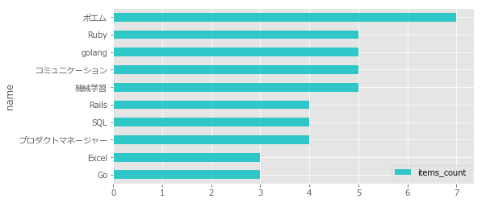

```python
df = read_sql('''
    SELECT
        name, COUNT(*) AS items_count
    FROM
        tags
    GROUP BY
        name
    ORDER BY
        items_count DESC
''', con)
df[:10].iloc[::-1].plot.barh(x='name', y='items_count', color='c', alpha=0.8, figsize=(8, 4))
```

## カレンダー毎に目立ったキーワードは？

[figure not shown]

いかがでしたか？

記事の内容をみてみると、また違った光景が現れて面白いですね！

それでは最後に運営からのピックアップをご紹介して終わりたいと思います。

## 新人賞

リブセンスアドベントカレンダーに今年初参加の人によるもので

最もいいね数が多かった記事。

### 🏆受賞者🏆

[「賢い大人」たちが発するメッセージは「一緒に考えよう」だけでいいじゃないか](https://qiita.com/inouetakuya/items/58e5fc12a8015882cfad) by inouetakuya

**330** いいね！

## 我田引水賞

「関」「自」「学」というテーマに絡めながら

想像しうる技術的トピックと最もかけ離れていた記事。

### 🏆受賞者🏆

[関取について調べてみた](https://qiita.com/passol78/items/4656d73e6a9f9d6003de) by passol78

「関」取

## チーム・リブセンス賞

今年社内で話題になった「チーム・リブセンス」

この言葉に最もふさわしい記事。

### 🏆受賞者🏆

[なんでもできる凄い人（mさん）から学んだこと【宮崎編】](https://qiita.com/goupiyomaru/items/7d0aebdae06da567ce3b) by goupiyomaru

※宮崎のgou/piyo/maruさんには、ささやかな副賞をお送りしました！

これにてコンテンツは終わりとなります。

最後までご覧いただき、ありがとうございました。

来年もまた気持ちを新たに頑張っていきましょう！

# ふろく

```python
# カレンダー取得
import re
from datetime import date

import requests
import lxml.html as html
from pandas import DataFrame

cal_urls = {
    "関": "https://qiita.com/advent-calendar/2017/livesense-kan",
    "学": "https://qiita.com/advent-calendar/2017/livesense-gaku",
    "自": "https://qiita.com/advent-calendar/2017/livesense-ji",
}

if input("Qiitaからカレンダーを取得しますか？ yes/no > ") == 'yes':
    items = []
    for calendar, url in cal_urls.items():
        print(url)
        body = requests.get(url).text
        dom = html.fromstring(body)
        for day_el in dom.xpath("//td[@class='adventCalendarCalendar_day']"):
            day = day_el.xpath("./p[@class='adventCalendarCalendar_date']/text()")[0]
            dt = date(2017, 12, int(day))
            user_id = day_el.xpath("./div[@class='adventCalendarCalendar_author']/a/@href")[0][1:]
            url = day_el.xpath("./div[@class='adventCalendarCalendar_comment']/a/@href")[0]
            item_id = re.match(r".+/items/([0-9a-f]+)", url).group(1)
            item = dict(id=item_id, calendar=calendar, date=dt, user_id=user_id, url=url)
            items.append(item)
    df = DataFrame(items, columns=['id', 'calendar', 'date', 'user_id', 'url'])
    df.to_csv('data/items.csv', index=None)
```

```python
# 記事取得
import json
import os
from pathlib import Path

import requests
from pandas import read_csv

ENDPOINT = "https://qiita.com/api/v2"
TOKEN = os.environ['QIITA_ACCESS_TOKEN']
HEADERS = {"Authorization": f"Bearer {TOKEN}"}

items_df = read_csv('data/items.csv')
items_dir = Path('data/items')
if input("Qiitaから記事を取得しますか？ yes/no > ") == 'yes':
    for i, row in items_df.iterrows():
        print(row['id'], row['calendar'], row['date'], row['user_id'])
        item_id = row['id']
        item_dir = items_dir / item_id
        item_dir.mkdir(parents=True, exist_ok=True)
        item = requests.get(f"{ENDPOINT}/items/{item_id}", headers=HEADERS).text
        item_json = json.dumps(json.loads(item, strict=False), ensure_ascii=False, indent=2)
        (item_dir / 'item.json').write_text(item_json)
```

```python
# いいね取得
import json
import os
from pathlib import Path

import requests
from pandas import read_csv

ENDPOINT = "https://qiita.com/api/v2"
TOKEN = os.environ['QIITA_ACCESS_TOKEN']
HEADERS = {"Authorization": f"Bearer {TOKEN}"}
MAX_PAGE_REQUEST_LIMIT = 100
PER_PAGE = 100

items_df = read_csv('data/items.csv')
items_dir = Path('data/items')
if input("Qiitaからいいね一覧を取得しますか？ yes/no > ") == 'yes':
    for i, row in items_df.iterrows():
        print(row['id'], row['calendar'], row['date'], row['user_id'])
        item_id = row['id']
        likes_dir = items_dir / item_id / 'likes'
        likes_dir.mkdir(parents=True, exist_ok=True)
        for page in range(1, MAX_PAGE_REQUEST_LIMIT + 1):
            params = {'page': page, 'per_page': PER_PAGE}
            res = requests.get(f"{ENDPOINT}/items/{item_id}/likes", headers=HEADERS, params=params)
            likes_json = json.dumps(json.loads(res.text, strict=False), ensure_ascii=False, indent=2)
            (likes_dir / f'{page:0>3d}.json').write_text(likes_json)

            total_count = int(res.headers['Total-Count'])
            if page * PER_PAGE >= total_count:
                break
```

```python
# データベース初期化
import sqlite3
from pathlib import Path

db_file = Path("data/dataset.db")
db_file.unlink()  # DB一旦削除
con = sqlite3.connect(str(db_file))
schema = Path("schema.sql").read_text()
for create_table_stmt in schema.split(';'):
    con.execute(create_table_stmt.strip())
con.commit()
```

```python
# 記事インデックス
import json
import sqlite3
from pathlib import Path

from pandas import read_csv

items_df = read_csv('data/items.csv')
con = sqlite3.connect("data/dataset.db", isolation_level=None)
for _, row in items_df.iterrows():
    item_file = Path(f'data/items/{row["id"]}/item.json')
    item = json.loads(item_file.read_text())
    user = item["user"]
    con.execute('''
        INSERT OR REPLACE INTO users(
            id, calendar_participation, name, description, profile_image_url,
            items_count, followees_count, followers_count
        ) VALUES (
            ?, ?, ?, ?, ?,
            ?, ?, ?
        )
    ''', (
        user["id"], True, user["name"], user["description"], user["profile_image_url"],
        user["items_count"], user["followees_count"], user["followers_count"]
    ))
    con.execute('''
        INSERT OR REPLACE INTO items(
            id, user_id, url, title, likes_count, comments_count,
            calendar_name, calendar_date, created_at, updated_at
        ) VALUES (
            ?, ?, ?, ?, ?, ?,
            ?, ?, ?, ?
        )
    ''', (
        item["id"], user["id"], item["url"], item["title"], item["likes_count"], item["comments_count"],
        row["calendar"], row["date"], item["created_at"], item["updated_at"]
    ))
    con.execute('''
        INSERT OR REPLACE INTO item_bodies(
            item_id, body, rendered_body
        ) VALUES (
            ?, ?, ?
        )
    ''', (
        item["id"], item["body"], item["rendered_body"]
    ))
    con.executemany('''
        INSERT OR REPLACE INTO tags(
            item_id, name
        ) VALUES (
            ?, ?
        )
    ''', [
        (item["id"], tag['name']) for tag in item["tags"]
    ])
```

```python
# いいねインデックス
import json
import sqlite3
from pathlib import Path

from pandas import read_csv

items_df = read_csv('data/items.csv')
con = sqlite3.connect("data/dataset.db", isolation_level=None)
for i, row in items_df.iterrows():
    item_id = row['id']
    for likes_file in Path(f'data/items/{item_id}/likes').glob('*.json'):
        likes = json.loads(likes_file.read_text())
        for like in likes:
            user = like['user']
            # 記事書いて無い人のみ
            if not con.execute('SELECT 1 FROM users WHERE id = ?', (user['id'],)).fetchone():
                con.execute('''
                    INSERT OR REPLACE INTO users(
                        id, calendar_participation, name, description, profile_image_url,
                        items_count, followees_count, followers_count
                    ) VALUES (
                        ?, ?, ?, ?, ?,
                        ?, ?, ?
                    )
                ''', (
                    user["id"], False, user["name"], user["description"], user["profile_image_url"],
                    user["items_count"], user["followees_count"], user["followers_count"]
                ))

            con.execute('''
                INSERT OR REPLACE INTO likes(
                    user_id, item_id, created_at
                ) VALUES (
                    ?, ?, ?
                )
            ''', (
                user["id"], row['id'], like['created_at']
            ))
```

```python
# キーワード抽出
from pathlib import Path

import lxml.html as html
import sqlite3

from mecab_wrapper import Parser

parser = Parser('ipadic')

STOPS_JA = Path('stopword-ja.txt').read_text().strip().split()
STOPS_EN = Path('stopword-en.txt').read_text().strip().split()
POSS = ('名詞', '動詞', '形容詞', '形容動詞')

def is_keyword_node(node):
    return node.pos in POSS and node.base not in STOPS_JA and node.base not in STOPS_EN

con = sqlite3.connect("data/dataset.db", isolation_level=None)

for item_id, rendered_body in con.execute('SELECT item_id, rendered_body FROM item_bodies').fetchall():
    dom = html.fromstring(rendered_body)
    code_els = dom.xpath('//code|//div[@class="code-frame"]')
    for code_el in code_els:
        code_el.getparent().remove(code_el)
    text = dom.text_content()
    nodes = parser.parse(text)
    keywords = [n.base for n in nodes if is_keyword_node(n)]
    con.execute('UPDATE item_bodies SET keywords = ? WHERE item_id = ?', (' '.join(keywords), item_id))
```

```python
# ワードクラウド用テキスト
from pathlib import Path
from pandas import read_sql

con = sqlite3.connect("data/dataset.db", isolation_level=None)
df = read_sql('''
    SELECT
        items.calendar_date,
        items.calendar_name,
        item_bodies.keywords
    FROM
        items
        INNER JOIN item_bodies
            ON items.id = item_bodies.item_id
''', con)

df = df.pivot(index='calendar_date', columns='calendar_name', values='keywords')
for col in df:
    keywords = ' '.join(df[col].tolist())
    Path(f'data/kw-{col}.txt').write_text(keywords)
```